# Data Science Summer School - MSR NYC

Nikola Baci and Yasiris Ortiz

6/21/2021

```r
suppressMessages(library(tidyverse))
suppressMessages(library(lubridate))
suppressMessages(library(gganimate))
```

## Small share of US police draw third of complaints in big cities

#### Article by [FINANCIAL TIMES](https://www.ft.com/content/141182fc-7727-4af8-a555-5418fa46d09e)

## Overview of the article

The [article](https://www.ft.com/content/141182fc-7727-4af8-a555-5418fa46d09e) published by Financial Times on May 28, 2021, one year after the death of George Floyd, tries to analyse the complaints that are filed against police officers in three major cities: NYC, Philadelphia, Chicago. The article points out that the ten percent of the officer with the most complaints received a third of all complaints during the period 2007-2017 for NYC and Chicago and 2015-2021 for Philly.

In this notebook, we are trying to replicate these finding and achieve the same bar graphs as article. In addition, we expand the notebook with further analysis such as the gender and the race of the officers that received the complaints.

## Data

Data for NYC can be found [here](https://github.com/new-york-civil-liberties-union/NYPD-Misconduct-Complaint-Database-Updated).

Data for Chicago can be found [1](https://github.com/invinst/chicago-police-data/blob/master/data/unified_data/complaints/complaints-accused.csv.gz), [2](https://github.com/invinst/chicago-police-data/blob/master/data/unified_data/complaints/complaints-complaints.csv.gz), [3](https://github.com/invinst/chicago-police-data/blob/master/data/unified_data/complaints/officer-filed-complaints__2017-09.csv.gz) and [4](https://github.com/invinst/chicago-police-data/blob/master/data/unified_data/complaints/complaints-complainants.csv.gz).

Data for Philadelphia can be found [1](https://github.com/sdl60660/philly_police_complaints/blob/master/raw_data/ppd_complaints.csv), [2](https://github.com/sdl60660/philly_police_complaints/blob/master/raw_data/ppd_complaints_7-18.csv), [3](https://github.com/sdl60660/philly_police_complaints/blob/master/raw_data/ppd_complaint_disciplines.csv), [4](https://www.opendataphilly.org/dataset/police-complaints/resource/e7477284-0045-4f37-8aeb-182616f736e8) and [5](https://www.opendataphilly.org/dataset/police-complaints/resource/7f7d472f-c49c-4364-b6e0-3a079e6b7d7f).

```r
nyc_data <- read.csv("data/nyc_misconduct_complaint_dataset.csv")

chicago_complaints_accused <- read.csv("data/chicago_complaints_accused.csv")

chicago_complaints_complaints <- read.csv("data/chicago_complaints_complaints.csv")

chicago_complaints_by_officers <- read.csv("data/chicago_officer_filed_complaints.csv")

philly_open_data_1 <- read.csv('data/ppd_complaints_open_philly.csv',header=T)

philly_open_data_2 <- read.csv('data/ppd_complaint_disciplines_open_philly.csv',header=T)

philly_sam_1 <- read.csv('data/philly_complaints_dataset_sam_cap_number.csv', header = T)

philly_sam_2 <- read.csv('data/philly_complaints_dataset_sam.csv',header=T)

philly_sam_3 <- read.csv('data/philly_complaints_disciplines_sam.csv')
```

## New York City

Replication of NYC bar graph from the article. We first create the necessary features and tables, then we proceed to graphing.

The resulting graph looks identical to the article.

### NYC Data Wrangling

```r
nyc_data_original <- nyc_data

nyc_data <- nyc_data %>%
  mutate(ReceivedDate = mdy(ReceivedDate)) %>% #convert from char to Date type
  filter(ReceivedDate >= "2007-01-01", ReceivedDate <= "2017-12-31") #get only the period between 2007-2017
```

### NYC Feature Engineering

```r
# Goal: Bucket each officer in one of the 10 buckets by the number of complaints.
# Note: Some complaints include several allegations for the same officer
# or for a number of officers
# Note: The names are not unique or sufficient to be used to identify each officer.

nyc_by_num_complaints <- nyc_data %>%
  group_by(OfficerID, ComplaintID) %>%
  summarize() %>%                                       # count one officer per complaint
  summarize(num_of_complaints = n()) %>%                # count the total complaints per officer
  arrange(num_of_complaints)                            # order in ascending order
total_complaints <- sum(nyc_by_num_complaints$num_of_complaints)  # sum of all complaints, used to obtain the percents for each bin

nyc_by_num_complaints <- nyc_by_num_complaints %>%
  mutate(bin_number = 1:nrow(nyc_by_num_complaints)) %>%  # create a new column to place the bin number 1 to 10
  mutate(bin_number = ntile(bin_number, 10)) # use the ntile function to put rows in the right bins

# collapse the table to only 10 rows that represent the bins
# for each bin find the percentage of the complaints that the bin has
# compared to the total
nyc_by_num_complaints <- nyc_by_num_complaints %>%
  group_by(bin_number) %>%
  summarize(total_complaints = (sum(num_of_complaints) / total_complaints) * 100)
```

### NYC Graphing

```r
nyc_by_num_complaints
```

```
## # A tibble: 10 x 2
##    bin_number total_complaints
##         <int>            <dbl>
##  1          1             4.10
##  2          2             4.10
##  3          3             4.10
##  4          4             4.10
##  5          5             5.23
##  6          6             8.19
##  7          7             8.74
##  8          8            12.3
##  9          9            17.4
## 10         10            31.7
```

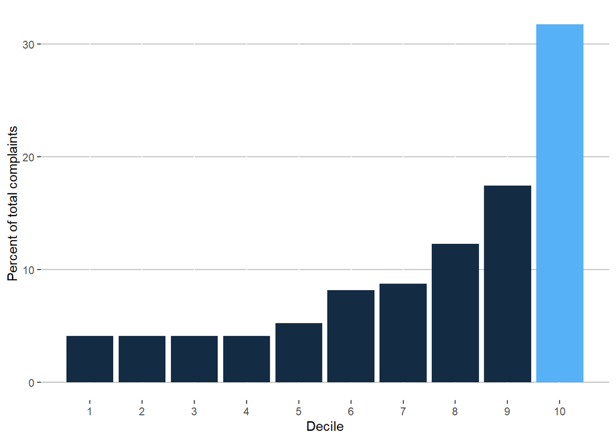

```r
nyc_by_num_complaints <-  nyc_by_num_complaints %>%
  mutate(color = c(rep(0, 9), 1)) # to help with the bar colors

# graph the deciles (bins) and their percentages
nyc_by_num_complaints %>%
  ggplot()+
  geom_histogram(aes(x = bin_number, y = total_complaints, fill = color), stat="identity", show.legend = F)+
  scale_x_continuous(breaks = seq(1, 10, 1)) + #set x-axis to go up by 1
  xlab("Decile")+
  ylab("Percent of total complaints") +
  theme(panel.background = element_rect(fill = "white", colour = "white",
                                size = 2, linetype = "solid"), # set background to white
          panel.grid.major.y = element_line(size = 0.5, linetype = 'solid',
                                colour = "gray")) # only horizontal marks
```

## Chicago

### Chicago Data Wrangling

Now we proceed to working with the Chicago data and obtaining the tables to draw the bars.

```r
chicago_accused_selected <-  chicago_complaints_accused %>%
  select(UID, cr_id, link_UID) #select only 3 out of the 10 columns

chicago_complaints_selected <- chicago_complaints_complaints %>%
  select(cr_id, complaint_date, closed_date) %>% #select only 3 out of the 11 columns
  mutate(complaint_date = ymd(complaint_date), closed_date = ymd(closed_date)) #turn char dates to Date-types

chicago_officers_selected <- chicago_complaints_by_officers %>%
  mutate(cr_id = as.character(cr_id)) #add a flag column, will help in keeping only the citizens complaints

#create a table that has three essential columns: officer id, complaint id, and data of complaint
chicago_complaints <- inner_join(chicago_accused_selected, chicago_complaints_selected, by="cr_id") %>%
  filter(complaint_date >= "2007-01-01",  closed_date <= "2017-12-31") #choose only period 2007-2017

#remove complaints that are done by officers or that are not closed yet
chicago_complaints_citizens <- anti_join(chicago_complaints, chicago_officers_selected, by="cr_id") %>%
   filter(!is.na(closed_date))
```

### Chicago Feature Engineering

```r
#Note: the code is the same as in NYC-Graph above, the only thing that changes is the
#data table in the next line and the variables to indicate that this data is for Chicago.
chicago_by_num_complaints <- chicago_complaints_citizens %>%
  group_by(UID, cr_id) %>%
  summarize() %>%
  summarize(num_of_complaints = n()) %>%
  arrange(num_of_complaints)
total_complaints <- sum(chicago_by_num_complaints$num_of_complaints)

chicago_by_num_complaints <- chicago_by_num_complaints %>%
  mutate(bin_number = 1:nrow(chicago_by_num_complaints)) %>%
  mutate(bin_number = ntile(bin_number, 10))

chicago_by_num_complaints <- chicago_by_num_complaints %>%
  group_by(bin_number) %>%
  summarize(total_complaints = (sum(num_of_complaints) / total_complaints) * 100)
```

### Chicago Graphing

Now we can graph the decile bars. Note: the data includes the only the citizen complaints that were registered on or after 01/01/2007 and were closed before 01/01/2018.

```r
chicago_by_num_complaints
```

```
## # A tibble: 10 x 2
##    bin_number total_complaints
##         <int>            <dbl>
##  1          1             2.07
##  2          2             2.07
##  3          3             3.01
##  4          4             4.13
##  5          5             5.79
##  6          6             7.40
##  7          7             9.62
##  8          8            13.0
##  9          9            18.3
## 10         10            34.6
```

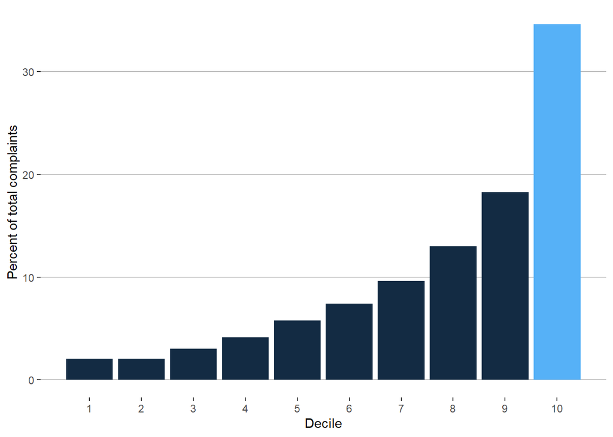

```r
chicago_by_num_complaints <-  chicago_by_num_complaints %>%
  mutate(color = c(rep(0, 9), 1))

chicago_by_num_complaints %>%
  ggplot()+
  geom_histogram(aes(x = bin_number, y = total_complaints, fill = color), stat="identity", show.legend = F)+
  scale_x_continuous(breaks = seq(1, 10, 1))+
  xlab("Decile")+
  ylab("Percent of total complaints") +
  theme(panel.background = element_rect(fill = "white", colour = "white",
                                size = 2, linetype = "solid"),
          panel.grid.major = element_line(size = 0.5, linetype = 'solid',
                                colour = "gray"),
          panel.grid.major.x = element_blank())
```

## Philadelphia

### Philly Data Wrangling

```r
philly_open_data_1 <- philly_open_data_1 %>%
  subset(select=-summary) %>%
  mutate(date_received = as.Date(date_received))

philly_open_data_join <- left_join(philly_open_data_2, philly_open_data_1, by='complaint_id') %>%
  filter(date_received >= '2015-04-01')

philly_sam_1 <- philly_sam_1 %>%
  mutate(date_received = as.Date(date_received))
philly_sam_1 <-  rename(philly_sam_1, complaint_id = cap_number, district_occurrence = dist_occurrence)


philly_sam_2 <- philly_sam_2 %>%
  mutate(date_received = mdy(date_received)) %>% # change the date format here
  select(-shortened_summary)


philly_sam_3 <-  philly_sam_3%>%
  select(complaint_id, officer_id)

philly_data <- bind_rows(philly_sam_1, philly_sam_2) %>%
  left_join(philly_sam_3, by="complaint_id") %>%
  filter(date_received >= "2015-01-01", ! is.na(officer_id))
```

### Philly Feature Engineering

```r
philly_by_num_complaints <- philly_data %>%
  group_by(officer_id, complaint_id) %>%
  summarize() %>%
  summarize(num_of_complaints = n()) %>%
  arrange(num_of_complaints)
total_complaints <- sum(philly_by_num_complaints$num_of_complaints)
philly_by_num_complaints <- philly_by_num_complaints %>%
  mutate(bin_number = 1:nrow(philly_by_num_complaints)) %>%
  mutate(bin_number = ntile(bin_number, 10))

philly_by_num_complaints <- philly_by_num_complaints %>%
  group_by(bin_number) %>%
  summarize(total_complaints = (sum(num_of_complaints) / total_complaints) * 100)
```

### Philly Graphing

```r
philly_by_num_complaints
```

```
## # A tibble: 10 x 2
##    bin_number total_complaints
##         <int>            <dbl>
##  1          1             5.33
##  2          2             5.33
##  3          3             5.33
##  4          4             5.33
##  5          5             5.33
##  6          6             7.77
##  7          7            10.7
##  8          8            11.0
##  9          9            16.2
## 10         10            27.8
```

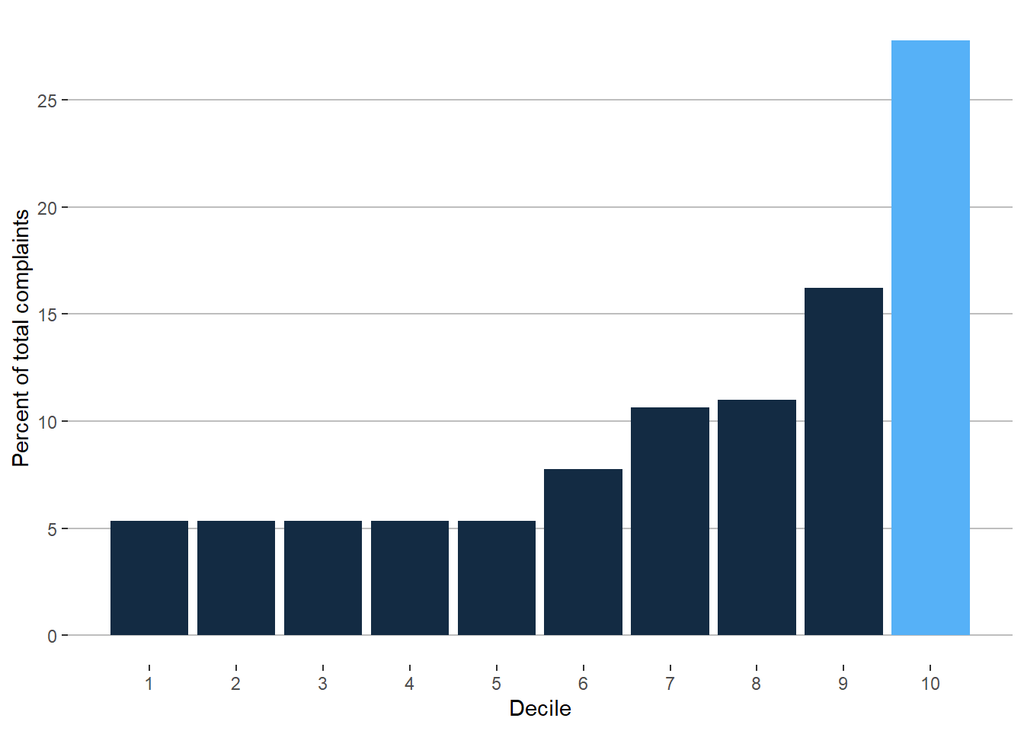

```r
philly_by_num_complaints <-  philly_by_num_complaints %>%
  mutate(color = c(rep(0, 9), 1))

philly_by_num_complaints %>%
  ggplot()+
  geom_histogram(aes(x = bin_number, y = total_complaints, fill = color), stat="identity", show.legend = F)+
  scale_x_continuous(breaks = seq(1, 10, 1))+
  scale_y_continuous(breaks = seq(0, 30, 5))+
  xlab("Decile")+
  ylab("Percent of total complaints") +
  theme(panel.background = element_rect(fill = "white", colour = "white",
                                size = 2, linetype = "solid"),
          panel.grid.major = element_line(size = 0.5, linetype = 'solid',
                                colour = "gray"),
          panel.grid.major.x = element_blank())
```

## Extended Analysis

### NYC Complaints by Officer Gender

```r
nyc_complaint_by_gender <- nyc_data %>%
  group_by(OfficerID, ComplaintID, OfficerGender) %>%
  suppressMessages(summarize()) %>%
  ungroup() %>%
  group_by(OfficerID) %>%
  summarize(num_of_complaints = n(), OfficerGender) %>%
  ungroup()
```

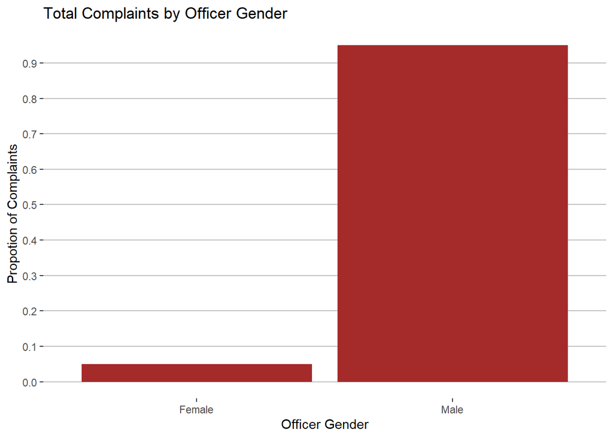

```r
#complaints by gender among all complaints
total_complaints <- sum(nyc_complaint_by_gender$num_of_complaints)
nyc_complaint_by_gender %>%
  group_by(OfficerGender) %>%
  summarize(percent = sum(num_of_complaints) / total_complaints) %>%
  ggplot() +
  geom_bar(aes(x = OfficerGender, y = percent), stat = "identity", show.legend = F, fill = "brown") +
  scale_y_continuous(breaks = seq(0, 1, 0.1)) +
  xlab("Officer Gender") +
  ylab("Propotion of Complaints") +
  labs(title = "Total Complaints by Officer Gender") +
  theme(panel.background = element_rect(fill = "white", colour = "white",
                                size = 2, linetype = "solid"),
          panel.grid.major = element_line(size = 0.5, linetype = 'solid',
                                colour = "gray"),
          panel.grid.major.x = element_blank())
```

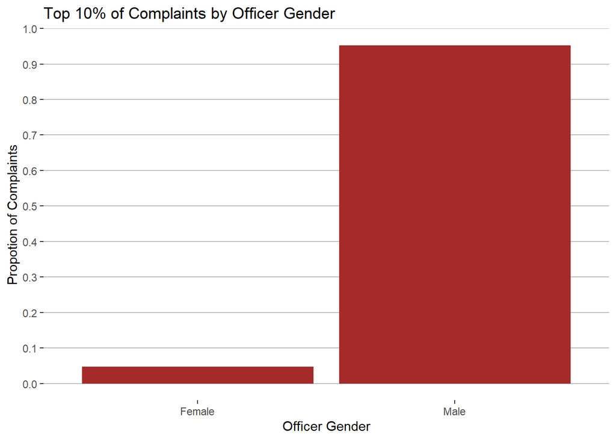

```r
#complaints by gender only bin 10
nyc_complaint_by_gender <- nyc_complaint_by_gender %>%
  mutate(bin_number = 1:nrow(nyc_complaint_by_gender)) %>% # create a new column to place the bin number 1 to 10
  mutate(bin_number = ntile(bin_number, 10)) %>%
  filter(bin_number == 10)

bin_10_total_complaints <- sum(nyc_complaint_by_gender$num_of_complaints)

nyc_complaint_by_gender %>%
  group_by(OfficerGender) %>%
  summarize(percent = sum(num_of_complaints) / bin_10_total_complaints) %>%
  ggplot() +
  geom_bar(aes(x = OfficerGender, y = percent), stat = "identity", show.legend = F,  fill = "brown") +
  scale_y_continuous(breaks = seq(0, 1, 0.1)) +
  xlab("Officer Gender") +
  ylab("Propotion of Complaints") +
  labs(title = "Top 10% of Complaints by Officer Gender") +
  theme(panel.background = element_rect(fill = "white", colour = "white",
                                size = 2, linetype = "solid"),
          panel.grid.major = element_line(size = 0.5, linetype = 'solid',
                                colour = "gray"),
          panel.grid.major.x = element_blank())
```

### Complaints by Officer Race

In this section we will analyze the race of the officers and what proportion of the complaints each race receives. Note: Please keep in mind that the we need more data to reach a conclusion. Things to keep in mind is the distribution of race in the police force as well as population of these cities. Hypothetical example, if NYC population is composed of 80% white and the police force has the same proportion of white officers, then it is more likely that the below bars will show an overwhelming amount of complaints towards white officers.

```r
nyc_complaints_by_officer_race <- nyc_data %>%
  group_by(OfficerID, ComplaintID, OfficerRace) %>%
  suppressMessages(summarize()) %>%
  ungroup()

nyc_complaints_by_officer_race <- nyc_complaints_by_officer_race %>%
  group_by(OfficerRace) %>%
  summarize(count = n()) %>%
  mutate(percent = count / nrow(nyc_complaints_by_officer_race) * 100)

nyc_complaints_by_officer_race
```

```
## # A tibble: 5 x 3
##   OfficerRace     count percent
##   <chr>           <int>   <dbl>
## 1 American Indian    96   0.100
## 2 Asian            4471   4.67
## 3 Black           15650  16.4
## 4 Hispanic        27282  28.5
## 5 White           48191  50.4
```

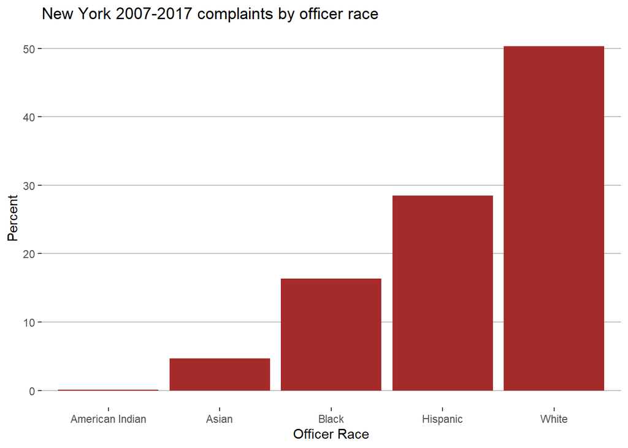

```r
nyc_complaints_by_officer_race %>%
  ggplot() +
  geom_bar(aes(x= OfficerRace, y = percent), stat = "identity", fill = "brown") +
  labs(title = "New York 2007-2017 complaints by officer race") +
  xlab("Officer Race") +
  ylab("Percent") +
  theme(panel.background = element_rect(fill = "white", colour = "white",
                                size = 2, linetype = "solid"),
          panel.grid.major = element_line(size = 0.5, linetype = 'solid',
                                colour = "gray"),
          panel.grid.major.x = element_blank())
```

The animation below shows the changes of the complaints that officers received, separated by their race, over the period 2007-2017.

```r
nyc_complaints_timeline <-  nyc_data %>%
  mutate(year = year(ReceivedDate)) %>%
  group_by(year, OfficerRace) %>%
  summarize(count = n())
```

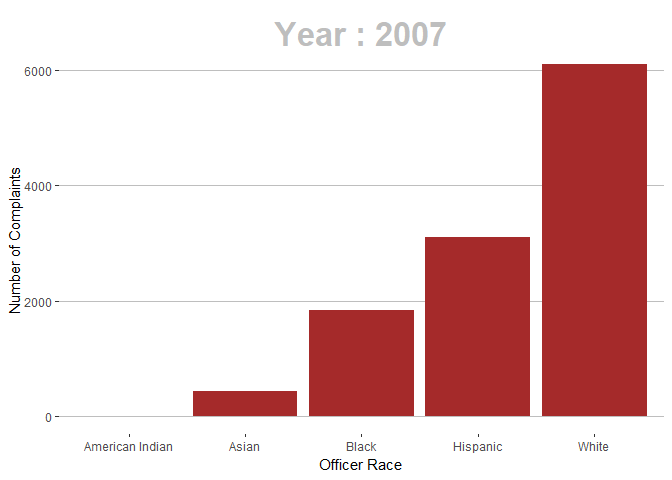

```r
plot_transition <- ggplot(data = nyc_complaints_timeline) +
  geom_bar(aes(x = OfficerRace, y = count), stat = "identity", fill = "brown") +
  xlab("Officer Race") +
  ylab("Number of Complaints") +
  theme(panel.background = element_rect(fill = "white", colour = "white",
                                size = 2, linetype = "solid"),
          panel.grid.major = element_line(size = 0.5, linetype = 'solid',
                                colour = "gray"),
          panel.grid.major.x = element_blank(),
        plot.title=element_text(size=25, hjust=0.5, face="bold", colour="grey", vjust=-1)) +
  transition_states(year, transition_length = 10, state_length = 1)+
  labs(title = 'Year : {closest_state}')

animate(plot_transition, fps=10)
```

#### Chicago

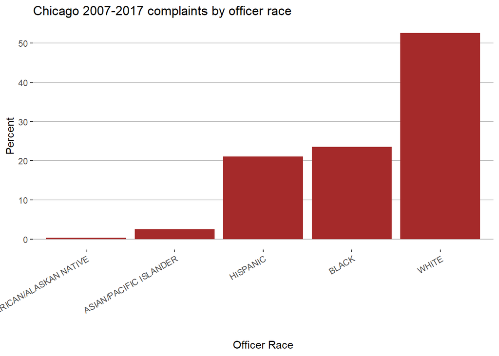

```r
chicago_officer_profiles <- read.csv("data/chicago_officer_profile.csv")
chicago_officer_profiles <- chicago_officer_profiles %>%
  select(UID, race)

chicago_complaints_and_officer <- left_join(chicago_complaints, chicago_officer_profiles, by="UID") %>%
  filter(race != "") #there is one officer whose race is unknown

chicago_complaints_by_offcier_race <- chicago_complaints_and_officer %>%
  group_by(UID, cr_id, race) %>%
  suppressMessages(summarize()) %>%
  ungroup()

chicago_complaints_by_offcier_race <- chicago_complaints_by_offcier_race %>%
  group_by(race) %>%
  summarize(count = n()) %>%
  mutate(percent = count / nrow(chicago_complaints_by_offcier_race) * 100) %>%
  mutate(race = factor(race)) %>%
  arrange(percent)

chicago_complaints_by_offcier_race %>%
  ggplot() +
  geom_bar(aes(x = fct_reorder(race, percent), y = percent), stat = "identity", fill = "brown") +
  labs(title = "Chicago 2007-2017 complaints by officer race") +
  xlab("Officer Race") +
  ylab("Percent") +
  theme(axis.text.x = element_text(angle = 30, hjust = 1)) +
  theme(panel.background = element_rect(fill = "white", colour = "white",
                                size = 2, linetype = "solid"),
          panel.grid.major = element_line(size = 0.5, linetype = 'solid',
                                colour = "gray"),
          panel.grid.major.x = element_blank())
```

### Distribution of Complaints by Officer Race

In this section we separate officers by their race and observer the count of officers by the number of complaints they have.

#### NYC

```r
nyc_complaints_distribution_by_officer_race <- nyc_data %>%
  group_by(OfficerID, ComplaintID, OfficerRace) %>%
  suppressMessages(summarize()) %>%
  ungroup

nyc_complaints_distribution_by_officer_race <-  nyc_complaints_distribution_by_officer_race %>%
  group_by(OfficerID, OfficerRace) %>%
  summarize(num_of_complaints = n())
```

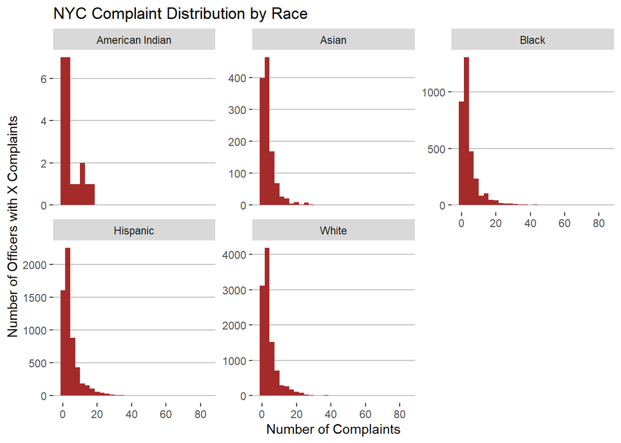

```r
nyc_complaints_distribution_by_officer_race %>%
  ggplot() +
  geom_histogram(aes(x = num_of_complaints), fill = "brown") +
  labs(title = "NYC Complaint Distribution by Race") +
  xlab("Number of Complaints") +
  ylab("Number of Officers with X Complaints") +
  facet_wrap(~ OfficerRace, scale = "free_y") +
  theme(panel.background = element_rect(fill = "white", colour = "white",
                                size = 2, linetype = "solid"),
          panel.grid.major = element_line(size = 0.5, linetype = 'solid',
                                colour = "gray"),
          panel.grid.major.x = element_blank())
```

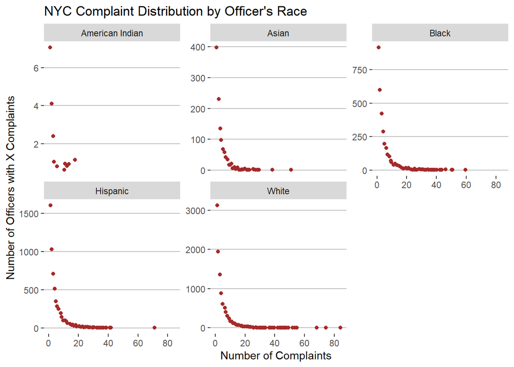

```r
nyc_complaints_distribution_by_officer_race %>%
  group_by(OfficerRace, num_of_complaints) %>%
  summarize(count = n()) %>%
  ggplot() +
  geom_jitter(aes(x = num_of_complaints, y = count), color = "brown") +
  labs(title = "NYC Complaint Distribution by Officer's Race") +
  xlab("Number of Complaints") +
  ylab("Number of Officers with X Complaints") +
  facet_wrap(~ OfficerRace, scales = "free_y") +
  theme(panel.background = element_rect(fill = "white", colour = "white",
                                size = 2, linetype = "solid"),
          panel.grid.major = element_line(size = 0.5, linetype = 'solid',
                                colour = "gray"),
          panel.grid.major.x = element_blank())
```

#### Chicago

```r
chicago_complaints_distribution_by_officer_race <- chicago_complaints_and_officer %>%
  group_by(UID, cr_id, race) %>%
  summarize() %>%
  ungroup
chicago_complaints_distribution_by_officer_race <-  chicago_complaints_distribution_by_officer_race %>%
  group_by(UID, race) %>%
  summarize(num_of_complaints = n())
```

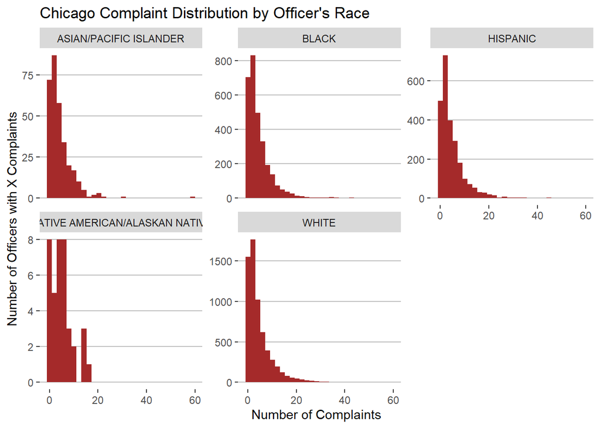

```r
chicago_complaints_distribution_by_officer_race %>%
  ggplot() +
  geom_histogram(aes(x = num_of_complaints), fill = "brown") +
  labs(title = "Chicago Complaint Distribution by Officer's Race") +
  xlab("Number of Complaints") +
  ylab("Number of Officers with X Complaints") +
  facet_wrap(~ race, scales = "free_y") +
  theme(panel.background = element_rect(fill = "white", colour = "white",
                                size = 2, linetype = "solid"),
          panel.grid.major = element_line(size = 0.5, linetype = 'solid',
                                colour = "gray"),
          panel.grid.major.x = element_blank())
```

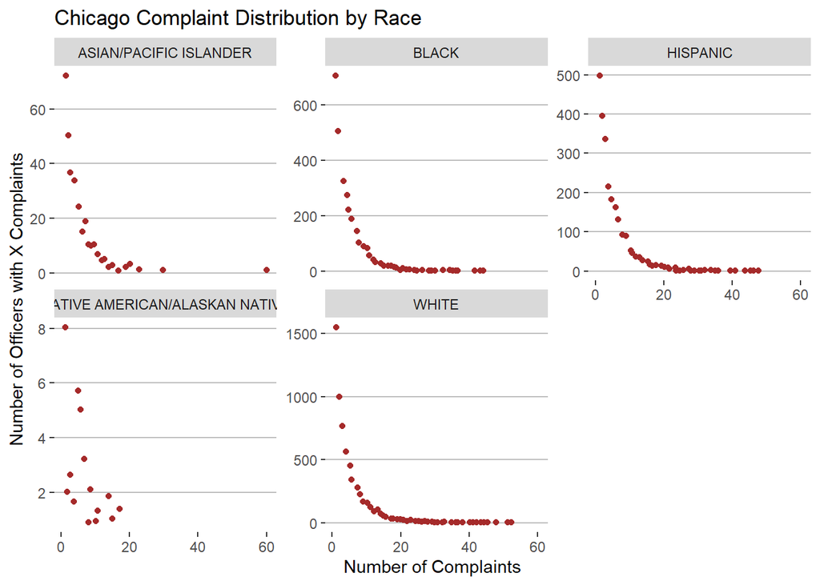

```r
chicago_complaints_distribution_by_officer_race %>%
  group_by(race, num_of_complaints) %>%
  summarize(count = n()) %>%
  ggplot() +
  geom_jitter(aes(x = num_of_complaints, y = count), color = "brown") +
  labs(title = "Chicago Complaint Distribution by Race") +
  xlab("Number of Complaints") +
  ylab("Number of Officers with X Complaints") +
  facet_wrap(~ race, scales = "free_y") +
  theme(panel.background = element_rect(fill = "white", colour = "white",
                                size = 2, linetype = "solid"),
          panel.grid.major = element_line(size = 0.5, linetype = 'solid',
                                colour = "gray"),
          panel.grid.major.x = element_blank())
```

### Distribution of Impacted Race by Officer Race

Lastly, we try to understand the distribution of the citizens that filed a complaint in NYC and Chicago during the 2007-2017 period.

Results show that the black community is filing more complaints.

#### NYC

```r
nyc_complaniant <- nyc_data %>%
  filter(ImpactedRace != "", ImpactedRace != "Unknown")

nyc_complaniant_distribution <- nyc_complaniant %>%
  group_by(OfficerID, ComplaintID, OfficerRace, ImpactedRace) %>%
  summarize() %>%
  ungroup
nyc_complaniant_distribution <-  nyc_complaniant_distribution %>%
  group_by(OfficerRace, ImpactedRace) %>%
  summarize(num_of_complaints = n())
```

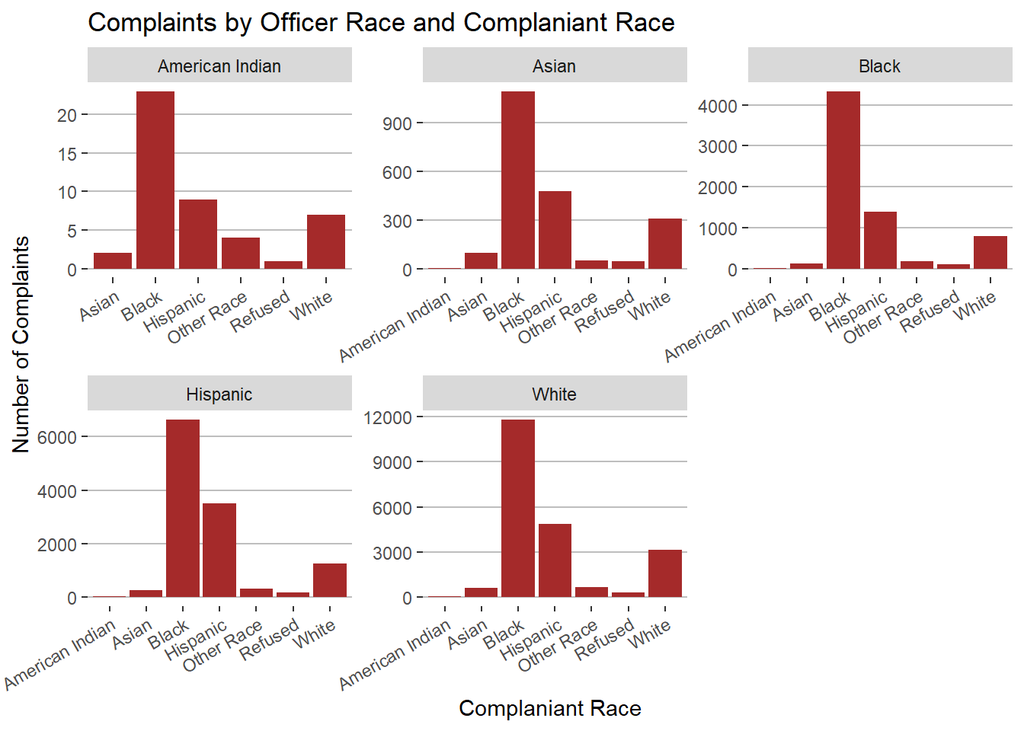

```r
nyc_complaniant_distribution %>%
  ggplot() +
  geom_bar(aes(x = ImpactedRace, y = num_of_complaints), stat = "identity", fill = "brown") +
  facet_wrap(~ OfficerRace, scales = "free") +
  labs(title = "Complaints by Officer Race and Complaniant Race") +
  xlab("Complaniant Race") +
  ylab("Number of Complaints") +
  theme(axis.text.x = element_text(angle = 30, hjust = 1)) +
  theme(panel.background = element_rect(fill = "white", colour = "white",
                                size = 2, linetype = "solid"),
          panel.grid.major = element_line(size = 0.5, linetype = 'solid',
                                colour = "gray"),
          panel.grid.major.x = element_blank())
```

#### Chicago

```r
chicago_complaniant <- read.csv("data/chicago-complaints-complainants.csv") %>%
  mutate(cr_id = as.character(cr_id)) %>%
  select(cr_id, race)

chicago_complaniant <- rename(chicago_complaniant, impacted_race = race)

chicago_complaints_and_officer <- rename(chicago_complaints_and_officer, officer_race = race)

chicago_complaniant <- chicago_complaints_and_officer %>%
  left_join(chicago_complaniant, by="cr_id") %>%
  filter(impacted_race != "", impacted_race != "Unknown")

chicago_complaniant_distribution <- chicago_complaniant %>%
  group_by(UID, cr_id, officer_race, impacted_race) %>%
  summarize() %>%
  ungroup
chicago_complaniant_distribution <-  chicago_complaniant_distribution %>%
  group_by(officer_race, impacted_race) %>%
  summarize(num_of_complaints = n())
```

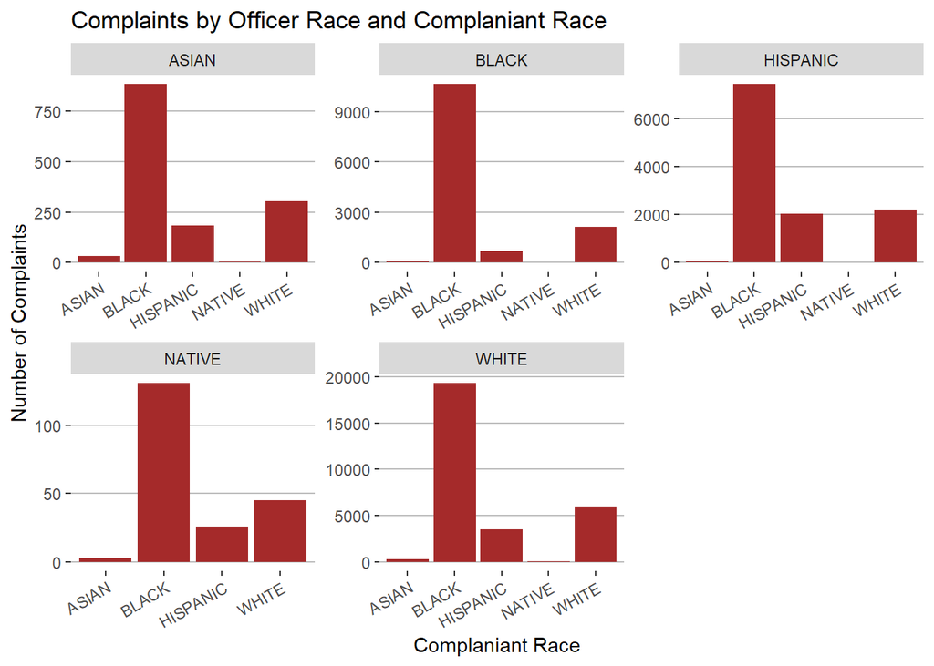

```r
chicago_complaniant_distribution$impacted_race[chicago_complaniant_distribution$impacted_race == "ASIAN/PACIFIC ISLANDER"] <- "ASIAN"
chicago_complaniant_distribution$officer_race[chicago_complaniant_distribution$officer_race == "ASIAN/PACIFIC ISLANDER"] <- "ASIAN"


chicago_complaniant_distribution$impacted_race[chicago_complaniant_distribution$impacted_race == "NATIVE AMERICAN/ALASKAN NATIVE"] <- "NATIVE"
chicago_complaniant_distribution$officer_race[chicago_complaniant_distribution$officer_race == "NATIVE AMERICAN/ALASKAN NATIVE"] <- "NATIVE"


chicago_complaniant_distribution %>%
  ggplot() +
  geom_bar(aes(x = impacted_race, y = num_of_complaints), stat = "identity", fill = "brown") +
  facet_wrap(~ officer_race, scales = "free") +
  labs(title = "Complaints by Officer Race and Complaniant Race") +
  xlab("Complaniant Race") +
  ylab("Number of Complaints") +
  theme(axis.text.x = element_text(angle = 30, hjust = 1)) +
  theme(panel.background = element_rect(fill = "white", colour = "white",
                                size = 2, linetype = "solid"),
          panel.grid.major = element_line(size = 0.5, linetype = 'solid',
                                colour = "gray"),
          panel.grid.major.x = element_blank())
```